# Part 2

Ethan Jantz

2/27/2022

# Introduction

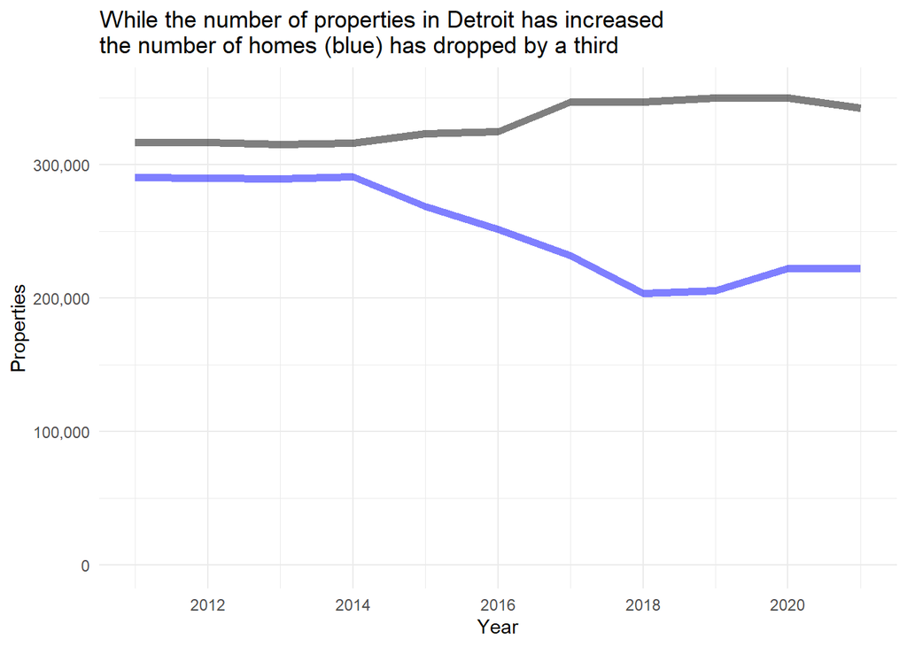

```r
properties <- assessments %>%
  count(year) %>%
  filter(year < as_date("2022-01-01"))

homes <- assessments %>%
  filter(propclass == 401) %>%
  count(year) %>%
  filter(year < as_date("2022-01-01"))

ggplot(data = NULL, aes(x = year, y = n)) +
  geom_line(data = properties, color = "black", size = 2, alpha = .5) +
  geom_line(data = homes, color = "blue", size = 2, alpha = .5) +
  scale_x_date(date_labels = "%Y", date_breaks = "2 year") +
  scale_y_continuous(labels = scales::comma,
                     limits = c(0, 355000)) +
  labs(title = "While the number of properties in Detroit has increased\nthe number of homes (blue) has dropped by a third",
       x = "Year", y = "Properties") +
  theme_minimal()
```

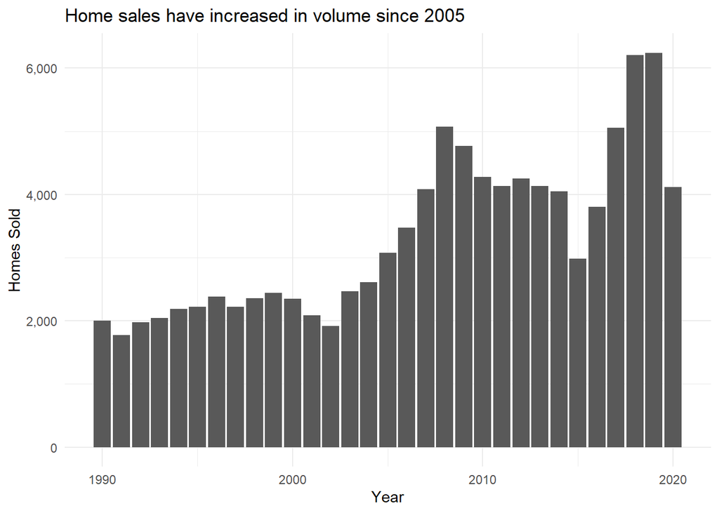

```r
parcels %>%
  mutate(sale_year = year(sale_date)) %>%
  select(sale_year, sale_price, assessed_value, property_class) %>%
  filter(sale_price > 4000, assessed_value > 2000, sale_year >= 1990, sale_year <= 2020, property_class == "401") %>%
  ggplot(aes(x = sale_year)) +
  geom_bar() +
  scale_y_continuous(labels = scales::comma) +
  labs(x = "Year", y = "Homes Sold",
       title = "Home sales have increased in volume since 2005") +
  theme_minimal()
```

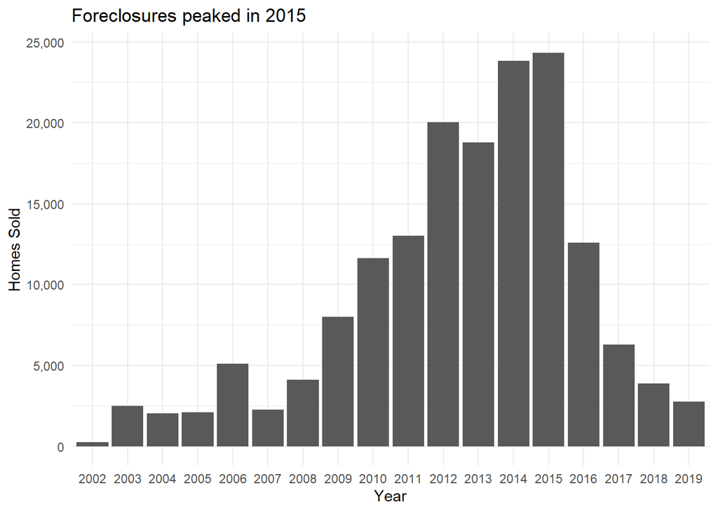

```r
foreclosures %>%
  pivot_longer(
    cols = c(`2002`:`2019`),
    names_to = "year"
  ) %>%
  group_by(year) %>%
  summarize(foreclosures = sum(value, na.rm = T)) %>%
  ggplot(aes(x = year, y = foreclosures)) +
  geom_col() +
  scale_y_continuous(labels = scales::comma) +
  labs(x = "Year", y = "Homes Sold",
       title = "Foreclosures peaked in 2015") +
  theme_minimal()
```

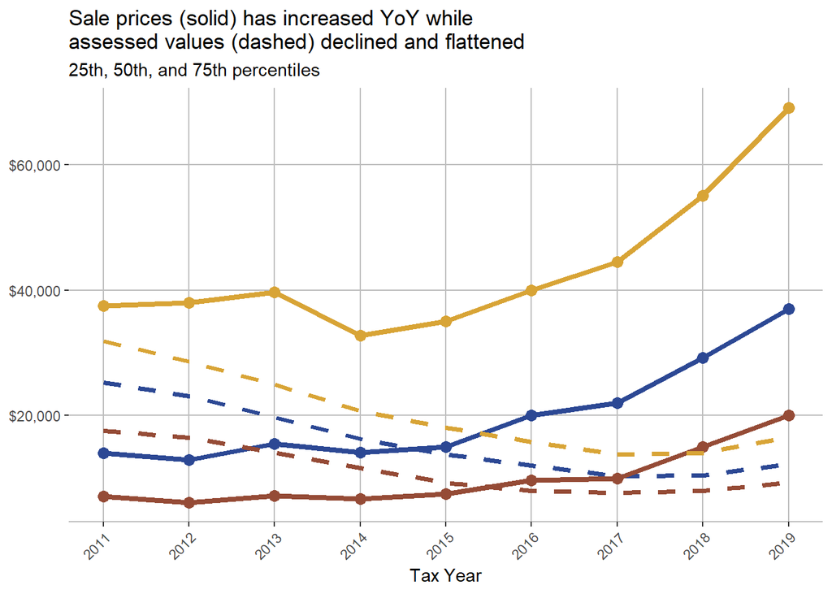

```r
output[[2]] +
  labs(title = "Sale prices (solid) has increased YoY while\nassessed values (dashed) declined and flattened")
```

## Predicting Overassessments

First we must define an over-assessment. According to [this report](https://harris.uchicago.edu/files/evalrespropertytaxasdetroit20162018.pdf) the legal limit is 50%. We’ll use this as the metric. Unfortunately I just don’t have time to go in-depth on this homework or I would spend more time on pre-modeling EDA to better determine which characteristics were most important to include. For now I”m going with the “throw spaghetti at the wall” approach and adding as many as I think are initially relevant.

```r
model_data <- assessments %>%
  left_join(
    sales %>%
      mutate(sale_year = as_date(sale_year)),
    by = c("PARCELNO" = "parcel_num")
)

model_data <- model_data %>%
  filter(year == "2016-01-01", year(sale_date) == 2016, property_c == "401",
         sale_price > 2500, ASSESSEDVALUE > 1250) %>%
  mutate(over = ifelse(ASSESSEDVALUE * 2 > sale_price, "Over", "Not") %>%
           as.factor())

model_data <- model_data %>%
  left_join(
    parcels %>%
      select(parcel_number, ward, zip_code, use_code_desc, total_square_footage, is_improved, style, year_built, zoning),
    by = c("PARCELNO" = "parcel_number")
  ) %>%
  mutate(is_improved = ifelse(is_improved == 1, T, F)) %>%
  filter(complete.cases(.)) # Removes ~700 rows
```

For this classification problem I will be using a random forest model. The recipe is going to convert NA values to unknown for zip code, style, and zoning values. Other than that I’m not going to mess with too much pre-processing on my first go.

```r
split <- initial_split(model_data)
train <- training(split)
test  <- testing(split)

rf_mod <-
  rand_forest(trees = 1000) %>%
  set_engine("ranger") %>%
  set_mode("classification")

rf_recipe <- recipe(over ~ sale_price + zip_code + is_improved + style + zoning,
                    data = train) %>%
  step_novel(all_nominal_predictors()) %>%
  step_unknown(all_nominal_predictors())

rf_workflow <- workflow() %>%
  add_model(rf_mod) %>%
  add_recipe(rf_recipe)

rf_fit <- fit(rf_workflow, train)

rf_preds <- augment(rf_fit, train)
```

Let’s create a classification matrix for this output using the `performanceEstimation` package that I found. fpr stands for false positive, fnr false negative, ppv predictive positive value, etc.

```r
performanceEstimation::classificationMetrics(rf_preds$over, rf_preds$.pred_class, metrics = c("fpr", "fnr", "tpr", "tnr", "ppv"))
```

```
##        fpr        fnr        tpr        tnr        ppv
## 0.05996366 0.18707224 0.81292776 0.94003634 0.87802875
```

Not bad!

```r
rf_test <- augment(rf_fit, test)

rf_test %>%
  select(PARCELNO, over, .pred_class) %>%
  count(over, .pred_class) %>%
  mutate(pct = n / sum(n))
```

| over | .pred_class | n | pct |
| --- | --- | --- | --- |
| Not | Not | 679 | 0.26859177 |
| Not | Over | 179 | 0.07080696 |
| Over | Not | 115 | 0.04549051 |
| Over | Over | 1555 | 0.61511076 |

```r
performanceEstimation::classificationMetrics(rf_test$over, rf_test$.pred_class, metrics = c("fpr", "fnr", "tpr", "tnr", "ppv"))
```

```
##        fpr        fnr        tpr        tnr        ppv
## 0.06886228 0.20862471 0.79137529 0.93113772 0.85516373
```

Still not bad, that’s pretty cool!

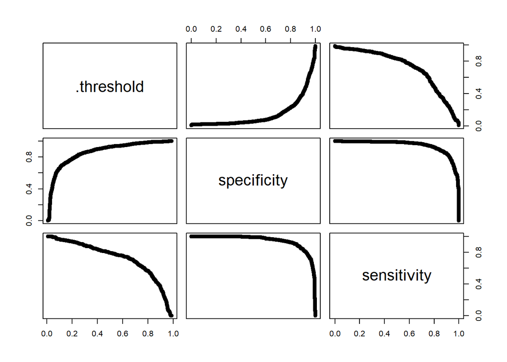

```r
roc <- yardstick::roc_curve(data = rf_test, truth = over, .pred_Not)

plot(roc)
```

## Predicting Assessed Values

```r
model_data <- assessments %>%
  left_join(
    sales %>%
      mutate(sale_year = as_date(sale_year)),
    by = c("PARCELNO" = "parcel_num")
)

model_data <- model_data %>%
  filter(year(year) <= 2019, year(year) >= 2016,
         year(sale_date) %in% c(2016:2019), property_c == "401",
         sale_price > 2500, ASSESSEDVALUE > 1250) %>%
  mutate(over = ifelse(ASSESSEDVALUE * 2 > sale_price, "Over", "Not") %>%
           as.factor())

model_data <- model_data %>%
  left_join(
    parcels %>%
      select(parcel_number, ward, zip_code, use_code_desc, total_square_footage, is_improved, style, year_built, zoning),
    by = c("PARCELNO" = "parcel_number")
  ) %>%
  mutate(is_improved = ifelse(is_improved == 1, T, F)) %>%
  filter(complete.cases(.)) # Removes ~700 rows
```

Same M.O. as the previous model. I’m going to make minimal changes to the data via recipe.

```r
split <- initial_split(model_data)
train <- training(split)
test  <- testing(split)

lm_mod <- linear_reg() %>%
  set_engine("lm") %>%
  set_mode("regression")

lm_recipe <- recipe(ASSESSEDVALUE ~ sale_price + total_square_footage +
                      year_built + is_improved + style,
                    data = train) %>%
  step_novel(all_nominal_predictors()) %>%
  step_unknown(all_nominal_predictors())

lm_workflow <- workflow() %>%
  add_model(lm_mod) %>%
  add_recipe(lm_recipe)

lm_fit <- fit(lm_workflow, train)

lm_preds <- augment(lm_fit, train %>% filter(year == "2019-01-01"))
```

```r
bind_rows(
  mape(lm_preds, truth = sale_price, estimate = .pred),
  rmse(lm_preds, truth = sale_price, estimate = .pred)
)
```

| .metric | .estimator | .estimate |
| --- | --- | --- |
| mape | standard | 72.3114 |
| rmse | standard | 87630.6892 |

```r
lm_preds <- augment(lm_fit, test %>% filter(year == "2019-01-01"))

bind_rows(
  mape(lm_preds, truth = sale_price, estimate = .pred),
  rmse(lm_preds, truth = sale_price, estimate = .pred)
)
```

| .metric | .estimator | .estimate |
| --- | --- | --- |
| mape | standard | 71.41202 |
| rmse | standard | 97139.11869 |

A little better, but it is a smaller sample. In the future I could try an approach that weights the data by recency, since we know the average trend in the housing market is “line go up”.